# Yandex project #9 Forecasts and Predictions.

Goal: to study data about gym chain clients using machine learning tools, trace churn reasons, and make marketing recommendations to lower it.

Step 1. General Information  
Step 2. Exploratory Data Analysis  
Step 3. Building a model to predict user churn  
Step 4. User clusters  
Step 5. Overall conclusions and basic recommendations on working with customers

### Step 1. General Information

```python
import pandas as pd
import numpy as np
import matplotlib.pyplot as plt
from matplotlib.pyplot import figure

import seaborn as sns

from sklearn.preprocessing import StandardScaler
from sklearn.metrics import accuracy_score, precision_score, recall_score

from scipy.cluster.hierarchy import dendrogram, linkage
from sklearn.cluster import KMeans

from sklearn.model_selection import train_test_split
from sklearn.ensemble import RandomForestClassifier
from sklearn.linear_model import LogisticRegression
from sklearn.metrics import mean_absolute_error, mean_squared_error, r2_score

pd.set_option('display.max_columns', 500)
gym_df = pd.read_csv('/datasets/gym_churn_us.csv')
gym_df.head()
```

|  | gender | Near_Location | Partner | Promo_friends | Phone | Contract_period | Group_visits | Age | Avg_additional_charges_total | Month_to_end_contract | Lifetime | Avg_class_frequency_total | Avg_class_frequency_current_month | Churn |
| --- | --- | --- | --- | --- | --- | --- | --- | --- | --- | --- | --- | --- | --- | --- |
| 0 | 1 | 1 | 1 | 1 | 0 | 6 | 1 | 29 | 14.227470 | 5.0 | 3 | 0.020398 | 0.000000 | 0 |
| 1 | 0 | 1 | 0 | 0 | 1 | 12 | 1 | 31 | 113.202938 | 12.0 | 7 | 1.922936 | 1.910244 | 0 |
| 2 | 0 | 1 | 1 | 0 | 1 | 1 | 0 | 28 | 129.448479 | 1.0 | 2 | 1.859098 | 1.736502 | 0 |
| 3 | 0 | 1 | 1 | 1 | 1 | 12 | 1 | 33 | 62.669863 | 12.0 | 2 | 3.205633 | 3.357215 | 0 |
| 4 | 1 | 1 | 1 | 1 | 1 | 1 | 0 | 26 | 198.362265 | 1.0 | 3 | 1.113884 | 1.120078 | 0 |

```python
gym_df.info()
```

```
<class 'pandas.core.frame.DataFrame'>
RangeIndex: 4000 entries, 0 to 3999
Data columns (total 14 columns):
gender                               4000 non-null int64
Near_Location                        4000 non-null int64
Partner                              4000 non-null int64
Promo_friends                        4000 non-null int64
Phone                                4000 non-null int64
Contract_period                      4000 non-null int64
Group_visits                         4000 non-null int64
Age                                  4000 non-null int64
Avg_additional_charges_total         4000 non-null float64
Month_to_end_contract                4000 non-null float64
Lifetime                             4000 non-null int64
Avg_class_frequency_total            4000 non-null float64
Avg_class_frequency_current_month    4000 non-null float64
Churn                                4000 non-null int64
dtypes: float64(4), int64(10)
memory usage: 437.6 KB
```

```python
gym_df.columns = map(str.lower, gym_df.columns)
gym_df['month_to_end_contract'] = gym_df['month_to_end_contract'].astype('int64')
```

```python
gym_df.duplicated().value_counts()
```

```
False    4000
dtype: int64
```

#### Conclusion

The data contains information about 4000 Model Fitness gym chain customers, 13 features - 6 of them are binary (like customer's gender or if they are a partners employee), others are non-binary like age. The target value is churn, showing those who quit (1) and those who stayed(0). The data is clean, no duplicates or missing values were found.

### Step 2. EDA

```python
gym_df.describe()
```

|  | gender | near_location | partner | promo_friends | phone | contract_period | group_visits | age | avg_additional_charges_total | month_to_end_contract | lifetime | avg_class_frequency_total | avg_class_frequency_current_month | churn |
| --- | --- | --- | --- | --- | --- | --- | --- | --- | --- | --- | --- | --- | --- | --- |
| count | 4000.000000 | 4000.000000 | 4000.000000 | 4000.000000 | 4000.000000 | 4000.000000 | 4000.000000 | 4000.000000 | 4000.000000 | 4000.000000 | 4000.000000 | 4000.000000 | 4000.000000 | 4000.000000 |
| mean | 0.510250 | 0.845250 | 0.486750 | 0.308500 | 0.903500 | 4.681250 | 0.412250 | 29.184250 | 146.943728 | 4.322750 | 3.724750 | 1.879020 | 1.767052 | 0.265250 |
| std | 0.499957 | 0.361711 | 0.499887 | 0.461932 | 0.295313 | 4.549706 | 0.492301 | 3.258367 | 96.355602 | 4.191297 | 3.749267 | 0.972245 | 1.052906 | 0.441521 |
| min | 0.000000 | 0.000000 | 0.000000 | 0.000000 | 0.000000 | 1.000000 | 0.000000 | 18.000000 | 0.148205 | 1.000000 | 0.000000 | 0.000000 | 0.000000 | 0.000000 |
| 25% | 0.000000 | 1.000000 | 0.000000 | 0.000000 | 1.000000 | 1.000000 | 0.000000 | 27.000000 | 68.868830 | 1.000000 | 1.000000 | 1.180875 | 0.963003 | 0.000000 |
| 50% | 1.000000 | 1.000000 | 0.000000 | 0.000000 | 1.000000 | 1.000000 | 0.000000 | 29.000000 | 136.220159 | 1.000000 | 3.000000 | 1.832768 | 1.719574 | 0.000000 |
| 75% | 1.000000 | 1.000000 | 1.000000 | 1.000000 | 1.000000 | 6.000000 | 1.000000 | 31.000000 | 210.949625 | 6.000000 | 5.000000 | 2.536078 | 2.510336 | 1.000000 |
| max | 1.000000 | 1.000000 | 1.000000 | 1.000000 | 1.000000 | 12.000000 | 1.000000 | 41.000000 | 552.590740 | 12.000000 | 31.000000 | 6.023668 | 6.146783 | 1.000000 |

- gender: there are ever so slightly more men than women in the gym.
- near_location: there are many more customers who live close to the gym.
- partner: slightly less than a half are partners company employees.
- promo_friends: There's less than a third of customers who were brought by a friend.
- phone: almost all the customers leave their phone number.
- contract_period: it varies a lot, with a mean of 4.7 months - more customers pay for one month than for 12 months.
- group_visits: a decent, close to half, amount of customers participate in group workouts.
- age: mean customer age is 29.2 years, with a range of 18-41.
- avg_additional_charges_total: additional spendings vary a lot, with an average of 147.
- month_to_end_contract: the data is spread good here, with a mean of 4.3 months till contract end.
- lifetime: average lifetime is 3.7 months, both beginners and long-time customers are represented in the dataset.
- avg_class_frequency_total: 1.87 visits per week is an average for customers' workouts.
- avg_class_frequency_current_month: for the preceding month the number is slightly lower - 1.76 times a week.

```python
features = gym_df.drop('churn', axis=1).columns
features
```

```
Index(['gender', 'near_location', 'partner', 'promo_friends', 'phone',
       'contract_period', 'group_visits', 'age',
       'avg_additional_charges_total', 'month_to_end_contract', 'lifetime',
       'avg_class_frequency_total', 'avg_class_frequency_current_month'],
      dtype='object')
```

```python
for i in features:
    m = gym_df.groupby('churn')[i].mean()
    s = gym_df.groupby('churn')[i].std()
    output = pd.merge(m, s, on='churn', suffixes=('_mean', '_std'))
    print(output)
    print('--------------------------------------------')
```

```
       gender_mean  gender_std
churn
0         0.510037    0.499984
1         0.510839    0.500118
--------------------------------------------
       near_location_mean  near_location_std
churn
0                0.873086           0.332933
1                0.768143           0.422217
--------------------------------------------
       partner_mean  partner_std
churn
0          0.534195     0.498914
1          0.355325     0.478837
--------------------------------------------
       promo_friends_mean  promo_friends_std
churn
0                0.353522           0.478144
1                0.183789           0.387495
--------------------------------------------
       phone_mean  phone_std
churn
0        0.903709   0.295040
1        0.902922   0.296204
--------------------------------------------
       contract_period_mean  contract_period_std
churn
0                  5.747193             4.716942
1                  1.728558             2.132371
--------------------------------------------
       group_visits_mean  group_visits_std
churn
0               0.464103          0.498795
1               0.268615          0.443448
--------------------------------------------
        age_mean   age_std
churn
0      29.976523  3.009933
1      26.989632  2.895163
--------------------------------------------
```

[output cut: 15 more lines]

```
       avg_class_frequency_total_mean  avg_class_frequency_total_std
churn
0                            2.024876                       1.016006
1                            1.474995                       0.694705
--------------------------------------------
       avg_class_frequency_current_month_mean  \
churn
0                                    2.027882
1                                    1.044546

       avg_class_frequency_current_month_std
churn
0                                   1.018994
1                                   0.770237
--------------------------------------------
```

- gender: churn almost equal between men and women.
- near_location: those who live close to the gym are less likely to leave. Greater data variance for quitters here tells us that location isn't everything when it comes to the decision to quit the gym.
- partner: churn is lower among users from partner companies.
- promo_friends: customers that brought by a friend are less likely to leave.
- phone: both who provided their phone number and who didn't have about the same chance to quit.
- contract_period: quitters have shorter contract periods. In terms of data spread - those who stay in the gym, have a variety of contracts, the data is very spread, and this is opposite to those who quit.
- group_visits: those who work out in groups prone to stay in the gym.
- age: younger customers tend to quit more, and data spread slightly less in those who quit, which tells us that quitters are younger in general.
- avg_additional_charges_total: quitters spend less on additional services. Data variance is greater in those who stay in the gym - it is not crucial to spend money on drinks in the gym to keep work out, but clients who don't spend money, are more likely to quit.
- month_to_end_contract: churn is higher toward contract's end.
- lifetime: beginners are prone to quit. And most of the quitters are beginners.
- avg_class_frequency_total: the more weekly visits a user has, the smaller chance he'll quit.
- avg_class_frequency_current_month: same for the preceding month, but the number of visits per week for quitters even lower than overall.

```python
quitters = gym_df.loc[gym_df['churn'] == 1]
loyals = gym_df.loc[gym_df['churn'] == 0]
```

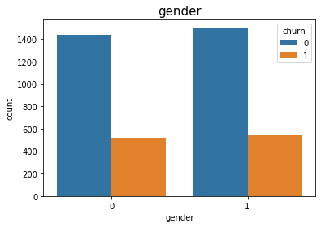

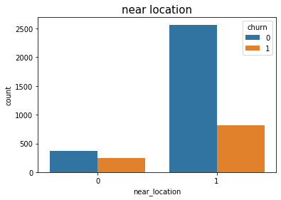

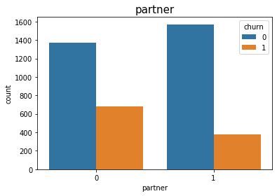

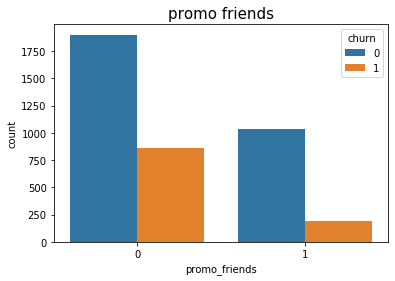

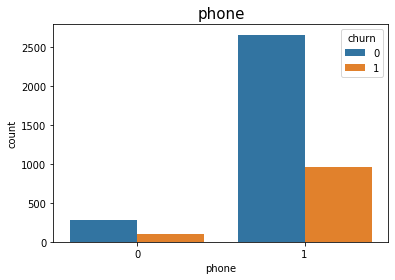

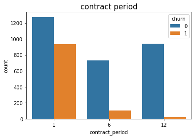

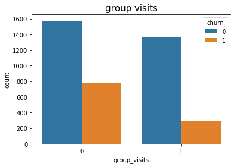

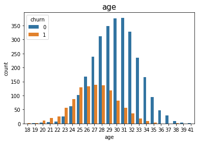

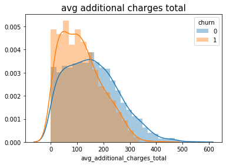

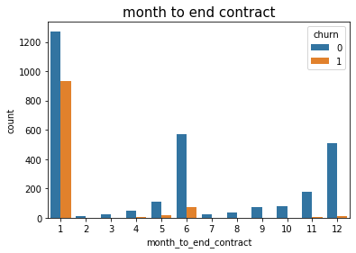

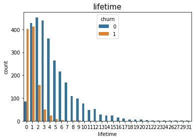

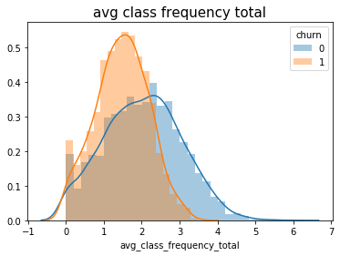

[1 more figures not shown]

```python
for i in features:
    plt.figure(figsize=(6,4))
    if (gym_df[i].dtype == np.float64):
        sns.distplot(loyals[i], label='0', hist=True)
        sns.distplot(quitters[i], label='1', hist=True)
        plt.title(i.replace('_', ' '), fontsize=15)
        plt.legend(title='churn')
    else:
        sns.countplot(x=i, hue='churn', data=gym_df)
        plt.title(i.replace('_', ' '), fontsize=15)
    plt.show()
```

- gender: a very similar distribution for men and women.
- near_location: there's not a lot of customers who live far from a gym, and the percent of quitters is higher among them.
- partner: our partners' employees are less likely to quit.
- promo_friends: friends bring loyal customers! We should consider further encouraging our customers to bring friends.
- phone: similar distributions of quitters here, doesn't look like this feature weights much.
- contract_period: we should motivate our customers for longer contracts if we want to reduce churn. Maybe adding a 3-month contract for those who don't want to buy longer contracts.
- group_visits: looks like group visits have an impact on churn.
- age: age distribution among quitters is clearly skewed towards younger customers.
- avg_additional_charges_total: quitters spend less, but there's a lot of loyal customers who come only to work out.
- month_to_end_contract: there is a lot of churns when one month is left till a contract ends, but those might be just users who bought a one-month contract - there's a similar rise in churn at 6 and 12-month marks. Also, there's not much sense in giving up on the 5th month if you bought a 6-month contract and enjoyed gym services for that long. The slight rise in churn at 5 months and 11-month marks tells us that these clients bought long contracts and quitted after the first month.
- lifetime: most people quit after one full month (or even after a couple of visits). There isn't a lot of loyal customers after 12 months, so it looks like they don't want to renew their contracts, we should pay attention to this.
- avg_class_frequency_total: the churn distribution is skewed towards fewer visits per week.
- avg_class_frequency_current_month: for loyal customers, the distribution looks the same as previous, but for churn, it is skewed even more towards fewer visits, and have an obvious spike on zero visits - since we consider that client churned when he stops visiting a gym. It must be a sign of quitting customer when his average weekly visits amount lowers.

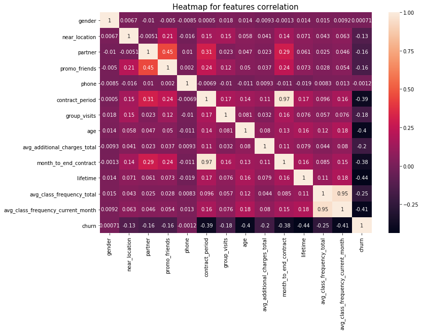

```python
cm = gym_df.corr()
plt.figure(figsize=(12,8))
sns.heatmap(cm, annot=True)
plt.title('Heatmap for features correlation', fontsize=15)
```

The strongest correlation is between the contract period and the month to end the contract. One of them should be omitted before building a model. The other strong correlation is between average visits per week for the preceding month and in general. Probably we should omit the latter.

#### Conclusion

The conducted EDA has given highlights for the features, some of them almost copy one another and should be removed before continuing. Some of the features were already discovered as correlated with churn, like the average age of quitting customers. A machine learning model should be build to try to predict churn based on the given features.

### Step 3. Building a model to predict user churn

In addition to model comparison, I want to test some of the features for their redundancy, based on EDA conducted. The features being tested are in the list below:

```python
features_to_check = ['complete_data', 'month_to_end_contract', 'contract_period',
                     'avg_class_frequency_total', 'avg_class_frequency_current_month', 'phone']
```

```python
X = gym_df.drop('churn', axis=1)
y = gym_df['churn']
X_train, X_test, y_train, y_test = train_test_split(X, y, test_size=0.2, random_state=0)
```

```python
models = [RandomForestClassifier(random_state=0), LogisticRegression(solver='lbfgs', max_iter=700, random_state=0)]

# the function that takes the model and data on input and outputs metrics
def make_prediction(m, X_train, y_train, X_test, y_test):
    model = m
    model.fit(X_train, y_train)
    y_pred = model.predict(X_test)
    print('Accuracy:{:.2f} Precision:{:.2f} Recall:{:.2f} '.format(accuracy_score(y_test, y_pred),
                                                                precision_score(y_test, y_pred),
                                                                recall_score(y_test, y_pred)))

for i in models: #iterate through models to compare
    print('--------------------------------------------')
    print(i)
    for j in features_to_check: #iterate through features that can be redundant, dropping them might improve metrics
        if (j != 'complete_data'):
            X_train_set = X_train.drop(j, axis=1)
            X_test_set = X_test.drop(j, axis=1)
        else:
            X_train_set = X_train
            X_test_set = X_test
        print('--------')
        print(j)

        make_prediction(i, X_train_set, y_train, X_test_set, y_test)
```

```
--------------------------------------------
RandomForestClassifier(bootstrap=True, class_weight=None, criterion='gini',
                       max_depth=None, max_features='auto', max_leaf_nodes=None,
                       min_impurity_decrease=0.0, min_impurity_split=None,
                       min_samples_leaf=1, min_samples_split=2,
                       min_weight_fraction_leaf=0.0, n_estimators='warn',
                       n_jobs=None, oob_score=False, random_state=0, verbose=0,
                       warm_start=False)
--------
complete_data
Accuracy:0.91 Precision:0.83 Recall:0.78
--------
month_to_end_contract
Accuracy:0.90 Precision:0.83 Recall:0.75
--------
contract_period
Accuracy:0.89 Precision:0.81 Recall:0.73
--------
avg_class_frequency_total
```

```
Accuracy:0.90 Precision:0.81 Recall:0.75
--------
avg_class_frequency_current_month
Accuracy:0.88 Precision:0.77 Recall:0.71
--------
phone
Accuracy:0.91 Precision:0.84 Recall:0.77
--------------------------------------------
LogisticRegression(C=1.0, class_weight=None, dual=False, fit_intercept=True,
                   intercept_scaling=1, l1_ratio=None, max_iter=700,
                   multi_class='warn', n_jobs=None, penalty='l2',
                   random_state=0, solver='lbfgs', tol=0.0001, verbose=0,
                   warm_start=False)
--------
complete_data
Accuracy:0.92 Precision:0.86 Recall:0.83
--------
month_to_end_contract
Accuracy:0.92 Precision:0.86 Recall:0.83
--------
contract_period
Accuracy:0.93 Precision:0.86 Recall:0.83
--------
avg_class_frequency_total
Accuracy:0.90 Precision:0.80 Recall:0.82
--------
avg_class_frequency_current_month
Accuracy:0.90 Precision:0.78 Recall:0.81
--------
phone
Accuracy:0.92 Precision:0.86 Recall:0.83
```

### Step 4. User clusters

```python
scaler = StandardScaler()
X_scaled = scaler.fit_transform(X)
linked = linkage(X_scaled, method = 'ward')
```

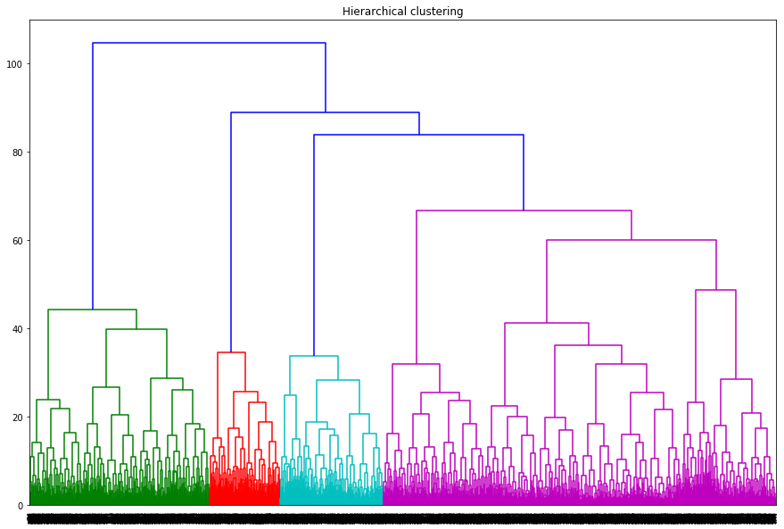

```python
plt.figure(figsize=(15, 10))
dendrogram(linked, orientation='top')
plt.title('Hierarchical clustering')
plt.show()
```

```python
km = KMeans(n_clusters = 5) # setting the number of clusters as 5
labels = km.fit_predict(X_scaled) # applying the algorithm to the data and forming a cluster vector
```

```python
gym_df['cluster'] = labels
cm = sns.light_palette('lightgreen', as_cmap=True)
gym_df.groupby('cluster').mean().style.background_gradient(cmap=cm, subset=features)
```

| cluster | gender | near_location | partner | promo_friends | phone | contract_period | group_visits | age | avg_additional_charges_total | month_to_end_contract | lifetime | avg_class_frequency_total | avg_class_frequency_current_month | churn |
| --- | --- | --- | --- | --- | --- | --- | --- | --- | --- | --- | --- | --- | --- | --- |
| 0 | 0.522078 | 0.862338 | 0.47013 | 0.306494 | 0 | 4.78701 | 0.425974 | 29.3013 | 143.958 | 4.47532 | 3.92468 | 1.84722 | 1.71637 | 0.267532 |
| 1 | 0.485737 | 1 | 0.350238 | 0.240095 | 1 | 1.94849 | 0.341521 | 28.168 | 131.622 | 1.85658 | 2.44057 | 1.24763 | 1.01298 | 0.514263 |
| 2 | 0.49505 | 0 | 0.463366 | 0.0792079 | 1 | 2.35248 | 0.215842 | 28.4772 | 135.458 | 2.19802 | 2.8099 | 1.66046 | 1.47732 | 0.443564 |
| 3 | 0.560335 | 0.976105 | 0.356033 | 0.229391 | 0.998805 | 2.66547 | 0.473118 | 30.1278 | 161.724 | 2.4552 | 4.89606 | 2.85153 | 2.84947 | 0.0681004 |
| 4 | 0.502473 | 0.959446 | 0.783383 | 0.574679 | 1 | 10.8843 | 0.543027 | 29.9802 | 160.707 | 9.95054 | 4.73887 | 1.9833 | 1.97623 | 0.0276954 |

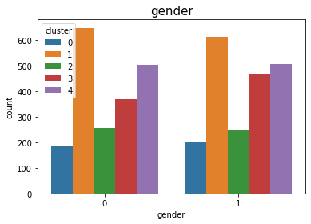

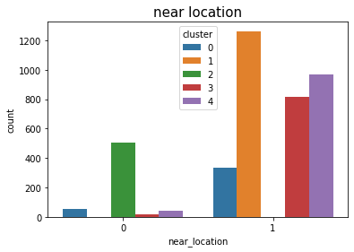

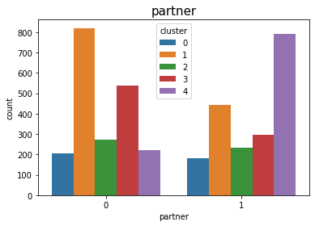

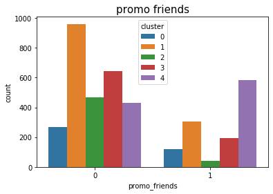

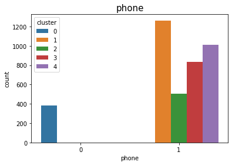

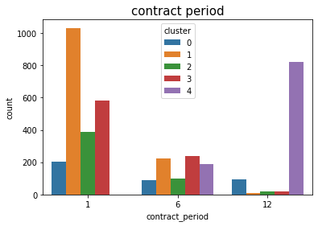

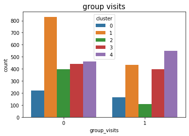

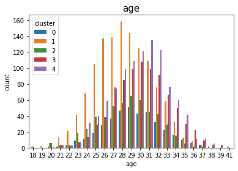

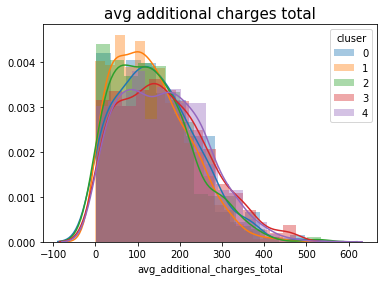

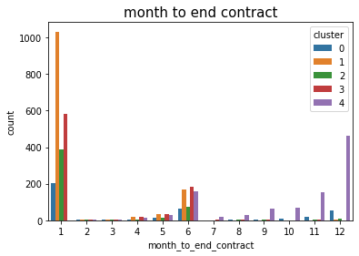

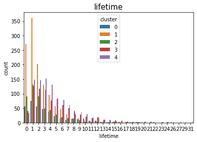

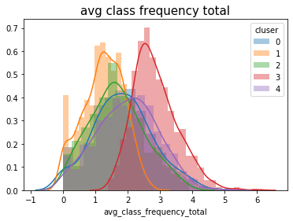

[1 more figures not shown]

```python
for i in features:
    plt.figure(figsize=(6,4))
    if (gym_df[i].dtype == np.float64):
        for j in range(0, gym_df.cluster.nunique()):
            sns.distplot(gym_df.query('cluster == @j')[i], label=j, hist=True)
            plt.legend(title='cluser')
    else:
        sns.countplot(x=i, hue='cluster', data=gym_df)
    plt.title(i.replace('_', ' '), fontsize=15)
    plt.show()
```

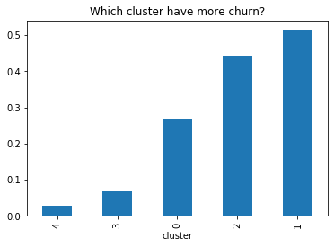

```python
gym_df.groupby('cluster').mean()['churn'].sort_values().plot(kind='bar')
plt.title('Which cluster have more churn?')
```

#### Conclusion

There were found 5 clients cohort using machine learning. Some cohorts are described by distinctive common features (those who don't live close to a gym), others share features between cohorts. Churn rate also varies between cohorts and might be predicted. Based on these features and cohorts we may proceed to conclusions and marketing recommendations.

### Step 5. Overall conclusions and basic recommendations on working with customers

The research was conducted to shed a light on features that influence customer's decision to quit working out in our gym chain. Based on machine learning models, we may name the main features: